# Ames house price prediction using lasso and ridge regression models

Applied Statistics Project 1 Team 1

June, 2019

## **Introduction**

One of the biggest pitfalls for building prediction models is the risk of overfitting the training dataset, resluting in poor prediction accuracy of the model. The reason for overfitting is that with the increased number of predictors, the model not only fits the signal, but also tried to fit the noise in the trainign data. Mainly, there are two ways to prevent overfitting, validation/cross-validation and regularization. The idea of validation is very straight forward. Before fitting a model, a small portion of training data is randomly setted aside and used for evaluating the accuracy of the model trained on the rest of data. any model with low training error, but has very high testing error is a typical overfitted model. In general, complicated models with many predictors are at higher risk of being overfitting. Thus, the key to prevent overfitting the training data is to keep the model simple (less predictors) and make the weights (coefficients) of predictors small. One popular way to do that is by including a regularization term in the model. Two shrinkage approaches, ridge and lasso, are the most popular regularization methods.

**Ridge model : minimize (RSS + $\lambda\sum_{j=1}^p (\beta_j)^2$)**

**Lasso model: minimize (RSS + $\lambda\sum_{j=1}^p |\beta_j|)$**

In the ridge model, a L2 regularization term $\lambda\sum_{j=1}^p (\beta_j)^2$ (also called L2 norm or ridge penalty), is introduced into the model to keep the coefficients from getting too large. Similarly, for the lasso model, a L1 regularization term $\lambda\sum_{j=1}^p |\beta_j|)$ (L1 norm or Lasso penalty), is included in the model to force some coefficients to zero. In this sense, these two models achieved at least two objectives, one is to keep the weights of predictors from getting too large, thus lowering the variation of prediction. The other is that both approaches essentially perform feature selection by forcing the weights of less important predictors close or equal to zero.

To choose the proper penalty terms for both ridge and lasso models, validation or cross-validation are used to find the lambda resulting in least amount of validation errors. In particular, cross validation is popular because it uses all the training dataset for model training and in addition most packages will automatically choose the best tuning parameter .

## **Data Description**

The Ames house price dataset on Kaggle (https://www.kaggle.com/c/house-prices-advanced-regression-techniques) is one of the most popular dataset for regression models. It is an updated and modern version of the traditional Boston Housing dataset. The training and testing (for competition) datasets each have data on about 1,500 houses sold from 2006 to 2010 in Ames, IA. Besides the response variable, SalePrice, the datasets contain about 80 predictive variables associated with the price of a typical house, such as its location (Neighborhood), size (Gross living area), quality and condition (OverallQual and OverallCond). And the predictors are a rich mixture of both numerical and categorical variables. The purpose of the project is to generate several predictive linear regression models, including OLS (ordinary least square model) and OLS with regularization (ridge and lasso models), and compare them in terms of predictive accuracy).

## **Exploratory Data Analysis**

### 1. Dealing with missing data

**After loading and combining the train and test datasets, we first checked for missing data in the combined dataset. For linear regression, it is critical to deal with missing data because any NAs will inevitablly lead to the failure for model training and prediction of test data.**

```r
colSums(is.na(total))
```

```
##            Id    MSSubClass      MSZoning   LotFrontage       LotArea
##             0             0             4           486             0
##        Street         Alley      LotShape   LandContour     Utilities
##             0          2721             0             0             2
##     LotConfig     LandSlope  Neighborhood    Condition1    Condition2
##             0             0             0             0             0
##      BldgType    HouseStyle   OverallQual   OverallCond     YearBuilt
##             0             0             0             0             0
##  YearRemodAdd     RoofStyle      RoofMatl   Exterior1st   Exterior2nd
##             0             0             0             1             1
##    MasVnrType    MasVnrArea     ExterQual     ExterCond    Foundation
##            24            23             0             0             0
##      BsmtQual      BsmtCond  BsmtExposure  BsmtFinType1    BsmtFinSF1
##            81            82            82            79             1
##  BsmtFinType2    BsmtFinSF2     BsmtUnfSF   TotalBsmtSF       Heating
##            80             1             1             1             0
##     HeatingQC    CentralAir    Electrical     X1stFlrSF     X2ndFlrSF
##             0             0             1             0             0
##  LowQualFinSF     GrLivArea  BsmtFullBath  BsmtHalfBath      FullBath
##             0             0             2             2             0
##      HalfBath  BedroomAbvGr  KitchenAbvGr   KitchenQual  TotRmsAbvGrd
##             0             0             0             1             0
##    Functional    Fireplaces   FireplaceQu    GarageType   GarageYrBlt
##             2             0          1420           157           159
##  GarageFinish    GarageCars    GarageArea    GarageQual    GarageCond
##           159             1             1           159           159
##    PavedDrive    WoodDeckSF   OpenPorchSF EnclosedPorch    X3SsnPorch
##             0             0             0             0             0
##   ScreenPorch      PoolArea        PoolQC         Fence   MiscFeature
##             0             0          2909          2348          2814
##       MiscVal        MoSold        YrSold      SaleType SaleCondition
##             0             0             0             1             0
##     SalePrice
##             0
```

**For several columns with lots of NAs, such as Alley and FireplaceQu, the NAs are actually a subcategory by themsleves, we replace these NAs with their own category ‘None’.**

```r
total$MiscFeature[is.na(total$MiscFeature)] <- 'None'#MiscFeature
total$FireplaceQu[is.na(total$FireplaceQu)] <- 'None'#FireplaceQu
total$Fence[is.na(total$Fence)] <- 'None'#Fence
total$Alley[is.na(total$Alley)] <- 'None'#Alley
total$PoolQC[is.na(total$PoolQC)] <- 'None'#Alley
```

**For columns with few NAs, we replaced them by their mean or 0 (numerical variables), mode (categorical variables). A few examples are included below. In particular, for LotFrontage, NAs are replaced by average lotfrontage in their own neighborhood, assuming that house are more similar in the same neighborhood. For dealing with additional columns with missing data, see RMarkdown code for details**

```r
total$MSZoning[is.na(total$MSZoning)] <- 'RL' #For MSZoning, 4 NA replaced by its mode (RL, 76.4%)
total$MasVnrArea[is.na(total$MasVnrArea)] <- 0 #MAsVnrArea, replace NA with 0
total$GarageArea[is.na(total$GarageArea)] <- 412 #GarageArea 1 NA replaced by the average size of detached garages

#LotFrontage NAs replaced by their neighborhood averages ('mean' column in frontage)
total1 <- total[!is.na(total$LotFrontage),]
Frontage <- total1%>%group_by(Neighborhood)%>%summarize(mean = as.integer(mean(LotFrontage)))
for (neighborhood in Frontage$Neighborhood){
  total$LotFrontage[is.na(total$LotFrontage)&total$Neighborhood == neighborhood] <- Frontage$mean[Frontage$Neighborhood==neighborhood]
}
```

### 2. Change some numerical variables into categorical and *vis versa*

**For MSSubClass, MoSold and YrSold, it makes more sense to set them as categorical variables.**

```r
#set the following three numerical variables as characters
total$MSSubClass <- as.character(total$MSSubClass)
total$MoSold <- as.character(total$MoSold)
total$YrSold <- as.character(total$YrSold)
```

**For quality and condition evaluations, it makes more sense to set them as numerical variables. One example ExterQual is shown below. For additional columns, include ExterCond, BsmtCond, BsmtQual, HeatingQC, KitchenQual, FireplaceQu and GarageQual, see RMarkdown file for details. Note that for some columns, we combined some categories because they have few data points.**

```r
#set categorical variable ExterQual as numerical
total$ExterQual[total$ExterQual == 'Fa'] <- 1
total$ExterQual[total$ExterQual == 'TA'] <- 2
total$ExterQual[total$ExterQual == 'Gd'] <- 3
total$ExterQual[total$ExterQual == 'Ex'] <- 4
total$ExterQual <- as.numeric(total$ExterQual)
```

### 3. For some additonal categorical variables, we combined some subcategories. Because some categories have few data points (less than 10), which can present challenges for prediction and cross validation. It is possible that they might be only present in test dataset and lead to prediction failure.__

**First, we find the subcategories with fewer than 10 samples.**

```r
categorical_cols = total[, !sapply(total, is.numeric)]#table with only categorical variables
dummy = data.frame(model.matrix(~.-1, categorical_cols))#one hot encode create dummy variables
colnames(dummy[, colSums(dummy)<10])#subcategories contain less than 10 samples
```

```
##  [1] "MSSubClass150"      "MSSubClass40"       "UtilitiesNoSeWa"
##  [4] "Condition1RRNe"     "Condition1RRNn"     "Condition2PosA"
##  [7] "Condition2PosN"     "Condition2RRAe"     "Condition2RRAn"
## [10] "Condition2RRNn"     "HouseStyle2.5Fin"   "RoofStyleShed"
## [13] "RoofMatlMembran"    "RoofMatlMetal"      "RoofMatlRoll"
## [16] "RoofMatlWdShake"    "RoofMatlWdShngl"    "Exterior1stAsphShn"
## [19] "Exterior1stBrkComm" "Exterior1stCBlock"  "Exterior1stImStucc"
## [22] "Exterior1stStone"   "Exterior2ndAsphShn" "Exterior2ndCBlock"
## [25] "Exterior2ndOther"   "Exterior2ndStone"   "FoundationWood"
## [28] "HeatingGrav"        "HeatingOthW"        "HeatingWall"
## [31] "ElectricalFuseP"    "ElectricalMix"      "FunctionalMaj2"
## [34] "FunctionalSev"      "MiscFeatureOthr"    "MiscFeatureTenC"
## [37] "SaleTypeCon"        "SaleTypeConLI"      "SaleTypeConLw"
## [40] "SaleTypeOth"
```

**Next, we can either delete all these subcategories (especially if it is not feasible to wrangle them manually), or deal with them individually by combining them with other subcategories with similar SalePrice distribution. An example how to do that is shown below. We plot the distribution of SalePrice against all MSSubClasses and combine subclass 40 and 150 with subclass 160 (they share similar distribution). We performed similar procedures for addtional 12 categorical variables (not shown, see Rmarkdown file for details). In addition, we dropped a couple of variables, Id and Utilities, because of their lack of prediction value.**

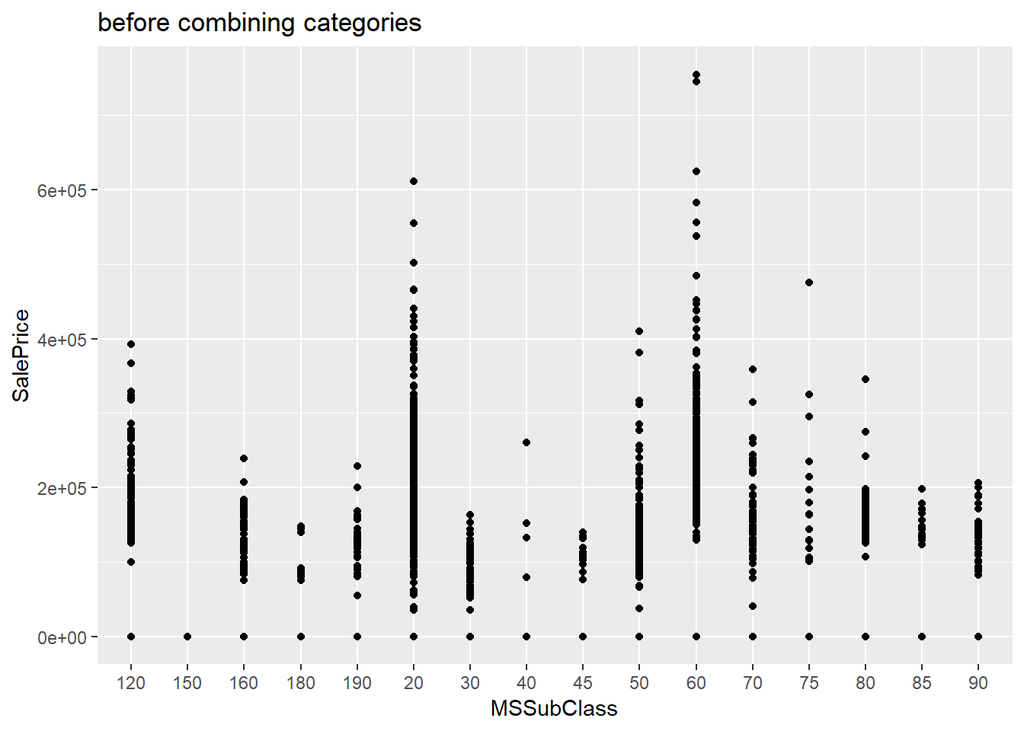

```r
#combined MSSubClass40 and 150 with MSSubClass160 according the following plot
ggplot(total, aes(MSSubClass, SalePrice))+geom_point()+ggtitle("before combining categories")
```

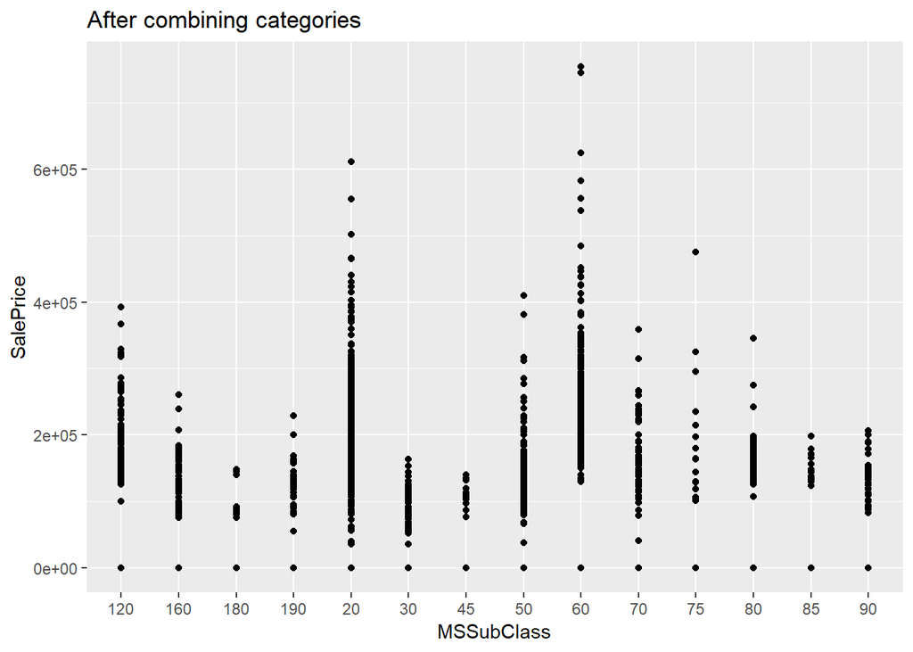

```r
total$MSSubClass[total$MSSubClass=='40'|total$MSSubClass=='150']= '160'
ggplot(total, aes(MSSubClass, SalePrice))+geom_point()+ggtitle('After combining categories')
```

### 4. Generate all dummy variables using one hot encode

```r
numeric_cols = total[, sapply(total, is.numeric)]#separate numerical and categorical variables
categorical_cols = total[, !sapply(total, is.numeric)]
dummy = data.frame(model.matrix(~.-1, categorical_cols))#one hot encode create dummy variables
total1 = cbind(dummy, numeric_cols)#regenerate the full table
```

### 5. Generate correlation martix, list and remove highly correlated variables (cutoff=0.9)

```r
corr = cor(total1)
table = as.data.frame(as.table(corr))
table = table[order(table$Freq),]
subset(table, abs(Freq) > 0.9 & table$Var1 != table$Var2)
```

```
##                       Var1                 Var2       Freq
## 15552         RoofStyleHip       RoofStyleGable -0.9562473
## 15974       RoofStyleGable         RoofStyleHip -0.9562473
## 28823           GarageCond       GarageTypeNone -0.9206019
## 29035           GarageCond     GarageFinishNone -0.9206019
## 42960       GarageTypeNone           GarageCond -0.9206019
## 42961     GarageFinishNone           GarageCond -0.9206019
## 42815           GarageCond           GarageQual  0.9012176
## 43026           GarageQual           GarageCond  0.9012176
## 2405        HouseStyleSLvl         MSSubClass80  0.9584278
## 15276         MSSubClass80       HouseStyleSLvl  0.9584278
## 17477   Exterior2ndMetalSd   Exterior1stMetalSd  0.9697117
## 19587   Exterior1stMetalSd   Exterior2ndMetalSd  0.9697117
## 701         BldgType2fmCon        MSSubClass190  0.9751185
## 13572        MSSubClass190       BldgType2fmCon  0.9751185
```

[output cut: 16 more lines]

```r
#remove highly correlated variables
highCorr = findCorrelation(corr, cutoff=.9)
total2 = total1[,-c(highCorr)]
```

### 6. Recovering train and test datasets

```r
train <- total2[total$SalePrice != 10, ]
test <- total2[total$SalePrice == 10, ]
```

### 7. looking for potential outliers in train dataset

**We first idenitfied the predictors that are highly correlated with the response variable SalePrice and plotted one of strong predictor GrLivArea against SalePrice and visually identified two potential datapoints (id =524 and 1299) with high leverage and influence (highlighted in red). We further fitted a preliminary full linear regression model and examined its residual vs leverage plot. Indeed, the same two data points have very large residuals, high leverage and cook’s D score (notice that Id= 1299 is actually literally off the chart!). In addition, further investigation confirmed that both are partial sales and likely not reflective their true sale prices. We removed these two outliers in part because of they have the largest living area (GrLivArea > 4500), yet both of them have exceptionally low sale prices.**

```r
#identify the highest corerlated predictors for the response variable SalePrice
corr = cor(train)
table = as.data.frame(as.table(corr))
table = table[order(table$Freq, decreasing =TRUE),]
corr1 = subset(table, table$Var1=='SalePrice')
head(corr1, 10)#Top 10 predictors
```

```
##            Var1        Var2      Freq
## 39601 SalePrice   SalePrice 1.0000000
## 31840 SalePrice OverallQual 0.7909816
## 35223 SalePrice   GrLivArea 0.7086245
## 32835 SalePrice   ExterQual 0.6826392
## 36616 SalePrice KitchenQual 0.6595997
## 37611 SalePrice  GarageCars 0.6404092
## 37810 SalePrice  GarageArea 0.6234314
## 33233 SalePrice    BsmtQual 0.6229247
## 34228 SalePrice TotalBsmtSF 0.6135806
## 34626 SalePrice   X1stFlrSF 0.6058522
```

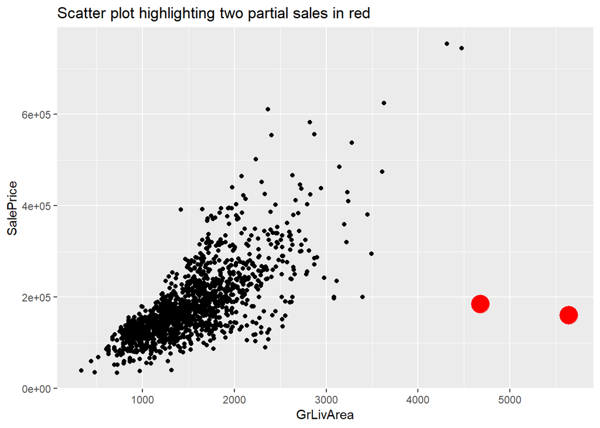

```r
#plot Saleprice vs one of its top predictors, GrLivArea, to visually identify outliers
ggplot(train, aes(GrLivArea, SalePrice))+geom_point()+ggtitle('Scatter plot highlighting two partial sales in red')+geom_point(data=train[train$GrLivArea>4500, ], aes(GrLivArea, SalePrice), colour="red", size=7)
```

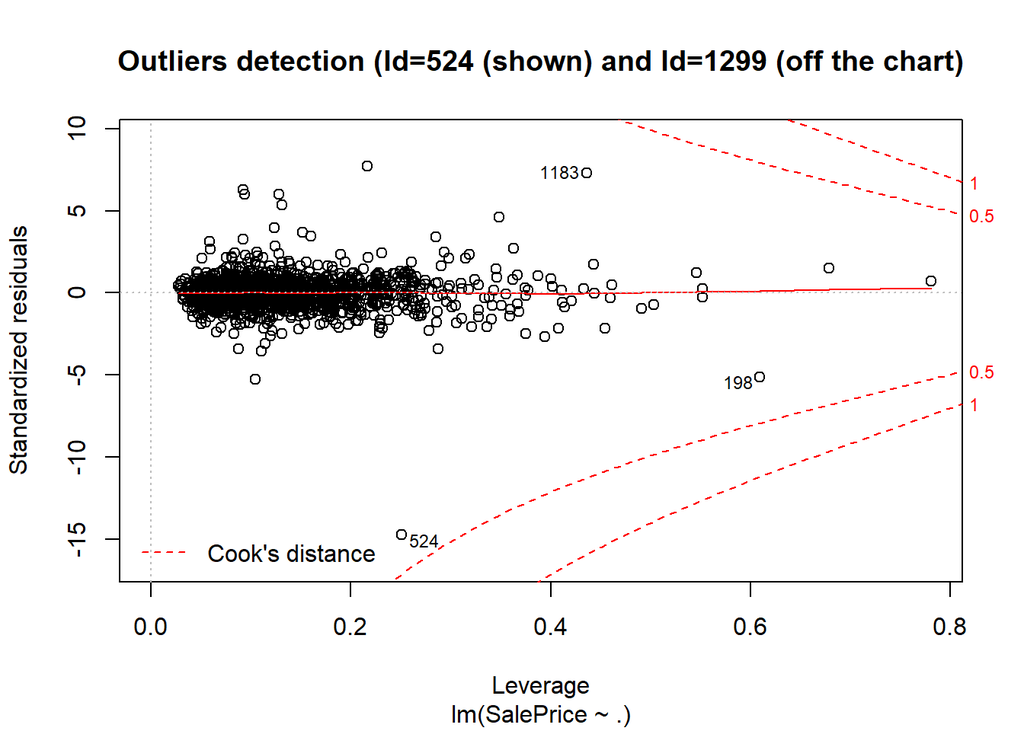

```r
#Another way to look at their leverage and influence by fitting a preliminary full linear regression model and examine its residual plots
Pre_model = lm(SalePrice~., data= train)
plot(Pre_model, which = 5, caption = NULL, main = 'Outliers detection (Id=524 (shown) and Id=1299 (off the chart)')
```

```r
#removing two large houses with exceptionally low sale price (presales, not reflective their true value)
train = train[train$GrLivArea<4500, ]
```

### 8. log transformation of SalePrice

**plotting SalePrice vs several of its strong predictors, such as OverallQual shown below, demonstrates a distictive curve, suggesting that logorithmic transformation of SalePrice might help fit the regression model better. Indeed, after SalePrice log transformation, the two variables appear to have a linear relationship.**

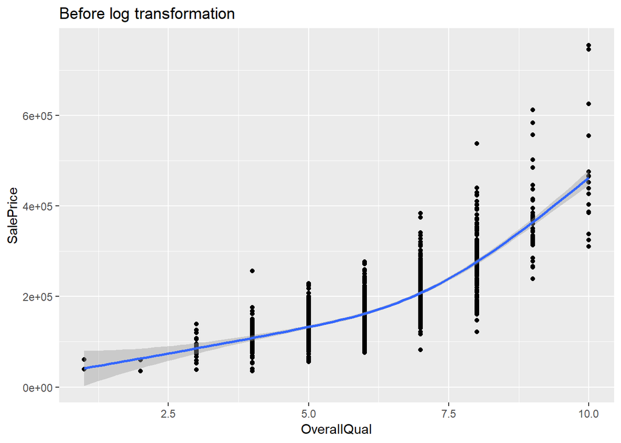

```r
ggplot(train, aes(OverallQual, SalePrice))+geom_point()+geom_smooth()+ggtitle('Before log transformation')
```

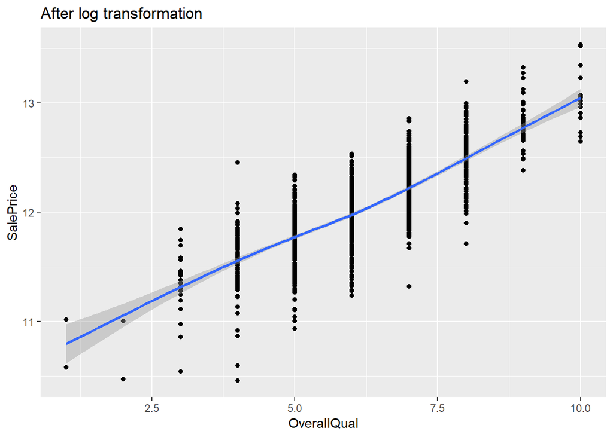

```r
train$SalePrice = log(train$SalePrice)#logtranformation of response variable SalePrice
ggplot(train, aes(OverallQual, SalePrice))+geom_point()+geom_smooth()+ggtitle('After log transformation')
```

## **Fitting models**

**After extensive data cleanup and transformation, we are ready to train regression models for predicting house prices. We are going to train three models: a regular linear regression model, also called ordinary least square (OLS) model, ridge and lasso regression model.**

### 1. First we set aside a test dataset by spliting the train dataset into train_train and train_test (8:2)

```r
set.seed(99)
index = createDataPartition(train$SalePrice, p=.8, list = F)
train_train = train[index, ]
train_test = train[-index, ]
```

### 2. setup training controls

```r
fit_control = trainControl(method = 'cv', number = 10)
```

### 3. fit the OLS model

**We first fitted full regression model, also called ordinary least square (OLS) model and assessed its residual plots for assumptions of linear regression. First of all, we have no reason to suspect that all sales are independent from each other and likely reflect their true value. Second, with the exception of houses with low predicted values (fitted values < 11.5), the variance is more or less constant. Third, from the QQ-plot, the assumption of normal distribution of residuals are less than ideal, significant deviation from linearity exists in both end of theoretical quantiles. Fourth, many predictors are indeed linearly correlated with the response variable, SalePrice. Thus, the linear regression model is likely a sufficient fit for the dataset.**

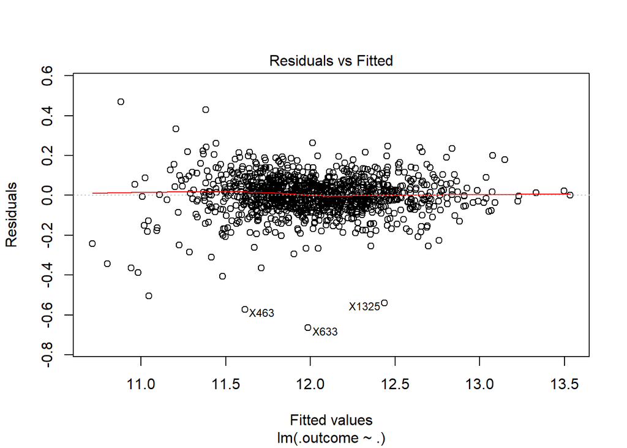

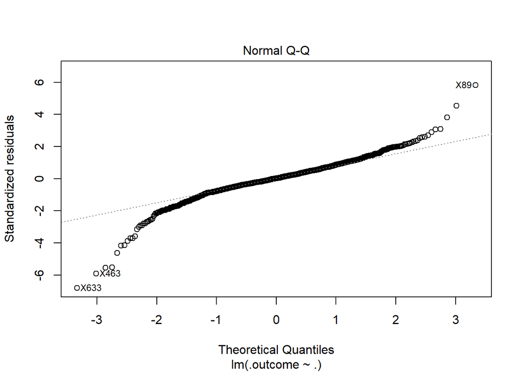

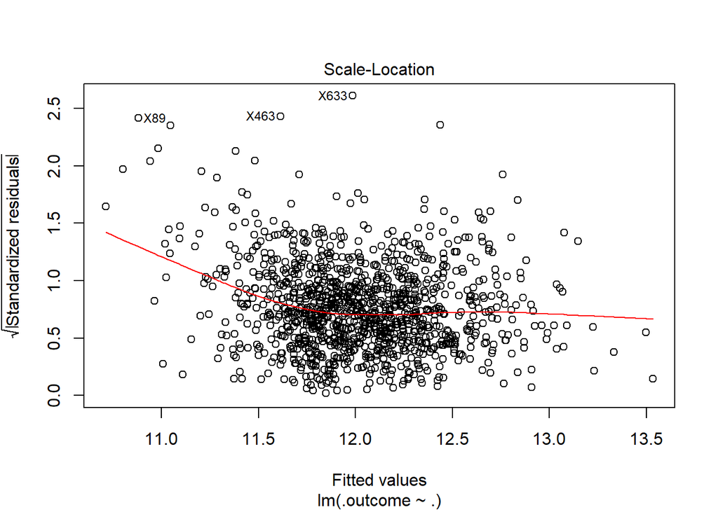

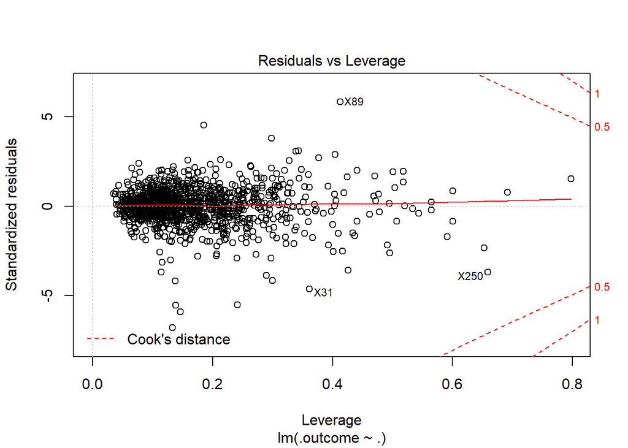

```r
full_model = train(SalePrice~., data=train_train, method = 'lm', trControl = fit_control)
plot(full_model$finalModel)#residual plots
```

### 4. fit the ridge model

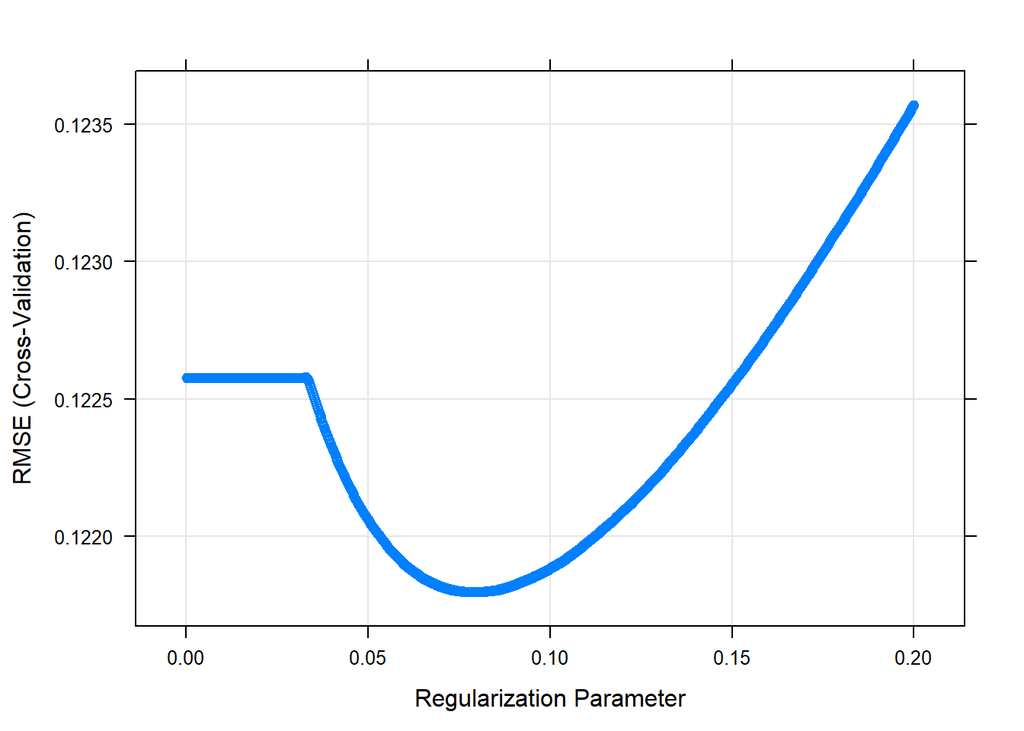

```r
ridge_model = train(SalePrice~., train_train, method='glmnet', preProc = c("center", "scale"), tuneGrid = expand.grid(alpha=0, lambda = seq(0.0001, .2, length = 1000)), trControl=fit_control)
plot(ridge_model)
```

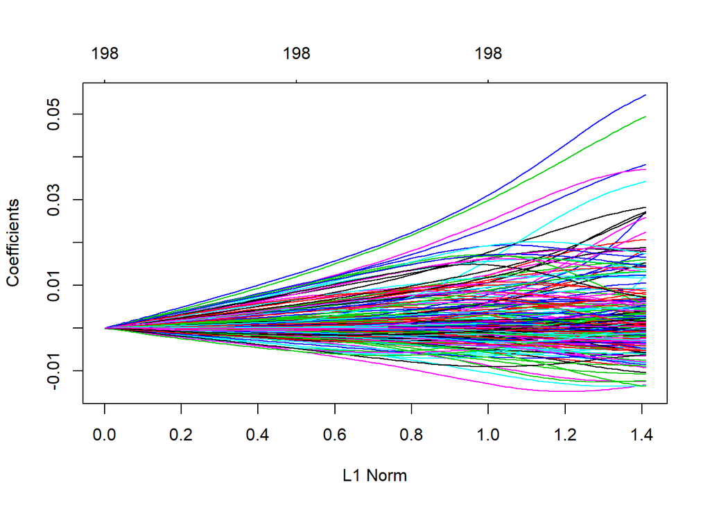

```r
plot(ridge_model$finalModel)
```

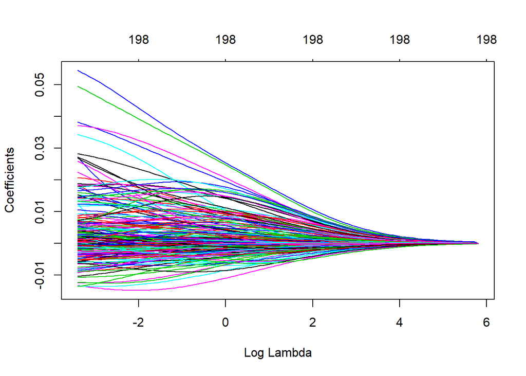

```r
plot(ridge_model$finalModel, 'lambda')
```

### 5. fit the lasso model

**We also fitted the asso model and used cross validation to choose the best tuning parameter lambda, which results in smallest MSE. We similarly noticed that the best tuning lambda value is rather small, suggesting that the training dataset contains a rich set of strong predictors and only small penalty term is necessary to achieve the best regularization.**

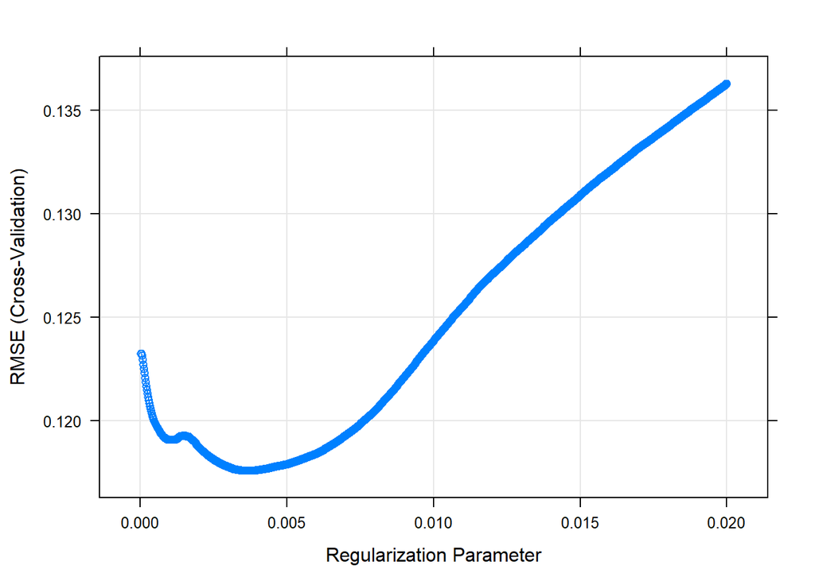

```r
lasso_model = train(SalePrice~., train_train, method='glmnet', preProc = c("center", "scale"), tuneGrid = expand.grid(alpha=1, lambda = seq(0.00001, 0.02, length = 1000)), trControl=fit_control)
plot(lasso_model)
```

```r
coef = coef(lasso_model$finalModel, lasso_model$bestTune$lambda)
paste('The number of predictors with non-zero coefficients in the Lasso model: ', sum(coef!=0))
```

```
## [1] "The number of predictors with non-zero coefficients in the Lasso model:  92"
```

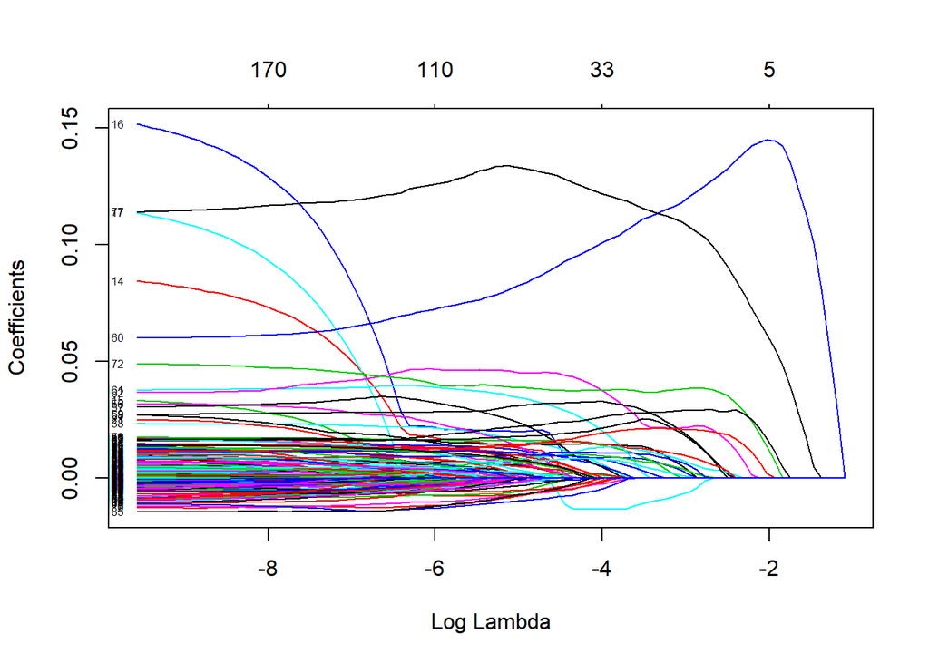

```r
plot(lasso_model$finalModel, 'lambda', label = TRUE)
```

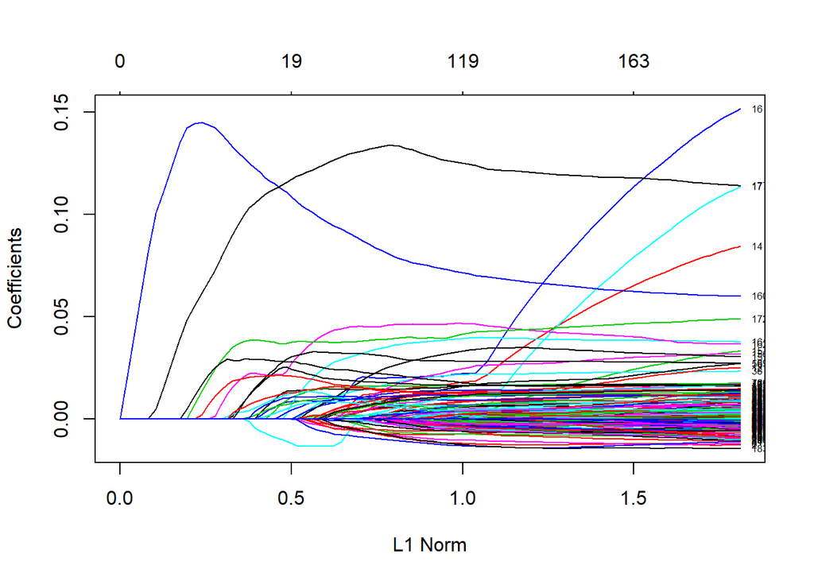

```r
plot(lasso_model$finalModel, 'norm', label = TRUE)
```

### 6. Comparing the models

```r
predict1 = predict(full_model, train_test)
OLS = postResample(predict1, train_test$SalePrice)
predict2 = predict(ridge_model, train_test)
Ridge = postResample(predict2, train_test$SalePrice)
predict3 = predict(lasso_model, train_test)
Lasso = postResample(predict3, train_test$SalePrice)
table = rbind(OLS, Ridge, Lasso)
table
```

```
##             RMSE  Rsquared        MAE
## OLS   0.11004399 0.9209650 0.07925006
## Ridge 0.10414333 0.9271675 0.07637990
## Lasso 0.09813157 0.9353413 0.07180475
```

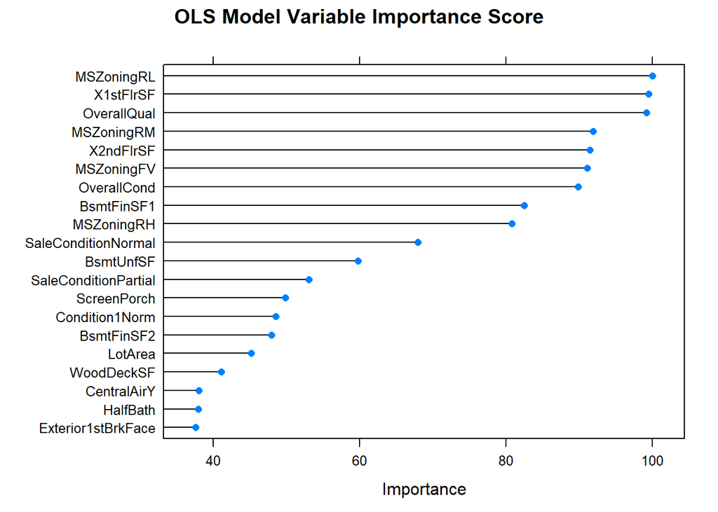

```r
par(mfrow=c(1,3))
plot(varImp(full_model), top=20, main='OLS Model Variable Importance Score')
```

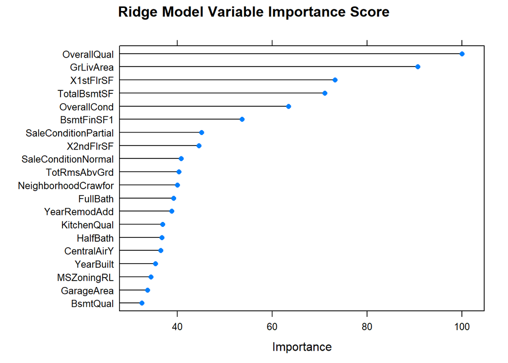

```r
plot(varImp(ridge_model, scale = T), top = 20, main='Ridge Model Variable Importance Score')
```

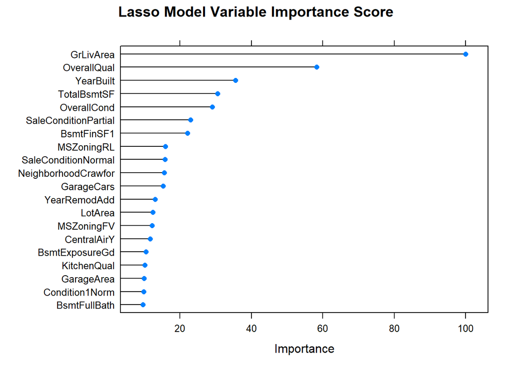

```r
plot(varImp(lasso_model), top =20, main= 'Lasso Model Variable Importance Score')
```